# Análise Discriminante Múltipla

```r
classiflgr <- ifelse(prob_posteriori > p, 1, 0)
classiflgr
```

```
##   4   6   9  16  20  23  26  30  34  38  40  48  64  66  71  72  79  81
##   0   0   0   0   1   0   0   1   0   0   0   0   0   0   0   1   0   1
##  83  91  99 102 103 114 117 120 122 124 126 130 132 135 140 143 148 153
##   0   0   0   0   1   0   0   0   0   0   0   1   1   0   0   1   1   0
## 158 160 162 164 170 174 176 180 181 185 191 193 194 197 198 202 204 206
##   0   0   0   0   0   1   1   0   0   1   0   0   0   1   1   0   1   1
## 210 217 218 237 242 244 245 247 249 257 258 259 260 276 281 282 284 290
##   0   1   1   1   1   1   1   1   1   0   0   0   1   0   0   1   0   0
## 293 294 296 297 298 301 302 309 317 321 322 324 326 329 334 345 351 353
##   0   1   1   1   0   0   1   1   0   1   1   1   1   1   1   1   1   1
## 361 363 367 373 374 383 387 394
##   1   1   0   1   1   1   1   1
```

```r
tablgr <- table(classiflgr, testeaval$classmpg)
tablgr
```

```
##
## classiflgr  0  1
##          0 44  7
##          1  6 41
```

```r
acurlrg <- (tablgr[1,1] + tablgr[2,2])/sum(tablgr)
acurlrg
```

```
## [1] 0.8673469
```

```r
treinoaval$classmpg <- as.factor(treinoaval$classmpg)
testeaval$classmpg <- as.factor(testeaval$classmpg)
```

A regra de classificação considerou a própria probabilidade *a priori* de um veículo pertencer a determinado grupo. Veículos que tiveram uma probabilidade de pertencer ao grupo 1, segundo a regressão logística, maior que a proporção de veículos do grupo 1, foram classificados em tal grupo.

A taxa de acerto, neste caso, foi maior que o obtido da análise discriminante.

```
(g) Faça agora uma árvore de decisão e avalie sua taxa de erro.
```

```r
set.seed(0)
library(rpart)

fitdtr <- rpart(classmpg ~ cylinders + displacement + horsepower + weight + acceleration + year + origin,
             method="class", data = treinoaval)
fitdtr
```

```
## n= 294
##
## node), split, n, loss, yval, (yprob)
##       * denotes terminal node
##
##  1) root 294 146 1 (0.496598639 0.503401361)
##    2) displacement>=0.03906588 126   5 0 (0.960317460 0.039682540) *
##    3) displacement< 0.03906588 168  25 1 (0.148809524 0.851190476)
##      6) weight>=-0.2178993 29  14 0 (0.517241379 0.482758621)
##       12) year< 0.9556623 19   4 0 (0.789473684 0.210526316) *
##       13) year>=0.9556623 10   0 1 (0.000000000 1.000000000) *
##      7) weight< -0.2178993 139  10 1 (0.071942446 0.928057554)
##       14) year< -0.6731187 31   9 1 (0.290322581 0.709677419)
##         28) weight>=-0.7070666 9   3 0 (0.666666667 0.333333333) *
##         29) weight< -0.7070666 22   3 1 (0.136363636 0.863636364) *
##       15) year>=-0.6731187 108   1 1 (0.009259259 0.990740741) *
```

```r
melhorCp = fitdtr$cptable[which.min(fitdtr$cptable[,"xerror"]),"CP"]
melhorCp
```

```
## [1] 0.01027397
```

```r
pfit <- prune(fitdtr, cp = melhorCp)
pfit
```

```
## n= 294
##
## node), split, n, loss, yval, (yprob)
##       * denotes terminal node
##
##  1) root 294 146 1 (0.49659864 0.50340136)
##    2) displacement>=0.03906588 126   5 0 (0.96031746 0.03968254) *
##    3) displacement< 0.03906588 168  25 1 (0.14880952 0.85119048)
##      6) weight>=-0.2178993 29  14 0 (0.51724138 0.48275862)
##       12) year< 0.9556623 19   4 0 (0.78947368 0.21052632) *
##       13) year>=0.9556623 10   0 1 (0.00000000 1.00000000) *
##      7) weight< -0.2178993 139  10 1 (0.07194245 0.92805755) *
```

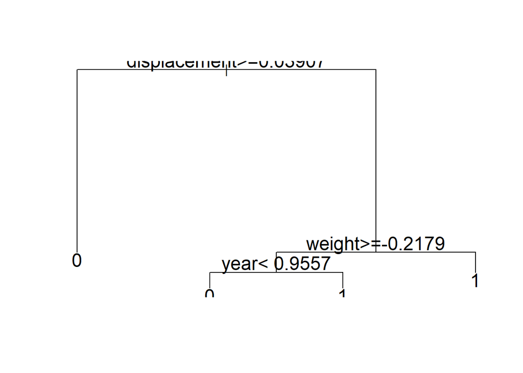

```r
plot(pfit)
text(pfit,use.n=FALSE,all=FALSE,cex=1.5)
```

```r
classifdtr <- predict(pfit, testeaval[,1:7], type = 'class')
tabdtr <- table(classifdtr, testeaval$classmpg)
tabdtr
```

```
##
## classifdtr  0  1
##          0 45  5
##          1  5 43
```

```r
acurdtr <- (tabdtr[1,1] + tabdtr[2,2])/sum(tabdtr)
acurdtr
```

```
## [1] 0.8979592
```

Este método de classificação obteve a maior taxa de acerto, embora não tão distante dos demais métodos.

```
(h) Utilize o método dos vizinhos mais próximos com k = 30 e avalie sua taxa de erro.
```

```r
library(class)
fitknn = knn(train = treinoaval[,1:7], test = testeaval[,1:7],
             cl = treinoaval$classmpg, k = 30)
tabknn <- table(fitknn, testeaval$classmpg)
tabknn
```

```
##
## fitknn  0  1
##      0 41  5
##      1  9 43
```

```r
acurknn <- (tabknn[1,1] + tabknn[2,2])/sum(tabknn)
acurknn
```

```
## [1] 0.8571429
```

o método de “k vizinhos mais próximos” obteve exatamente a mesma taxa de acerto das análises discriminantes linear e quadrática. Entretanto, tendendo a classificar mais observações como pertencentes à classe 1, mas não tanto quanto a LDA.